# Network Viz 5.16

2023-05-17

# Outstanding Questions

- Question 1: As for column titles, can these be anything? Lastly, what needs to be consistent across data sources (for example, does ‘id’ need to be in this particular format?)
- Question 2: What is the specific format that netplot requires things to be in?
- Question 3: In this particular data set, it is interesting to note that there is no baseline for what the map should look like. How does it determine how to sort these things?

# Source

This was all pulled from [this website](https://kateto.net/network-visualization).

# Important Packages

- igraph
- network
- sna
- ggraph
- visNetwork
- threejs
- networkD3
- ndtv

# Colors Exploration

- x: point coordinate
- y: point coordinate
- pch: point symbol shape

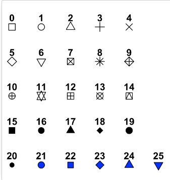

  - [Source](http://www.sthda.com/english/wiki/r-plot-pch-symbols-the-different-point-shapes-available-in-r)
- cex: point size
  - In R, the cex parameter is used to specify the size of text and symbols in a plot. Here are some of the commonly used options for cex:
    - Numeric values greater than 1 will increase the size of the text or symbol.
    - Numeric values between 0 and 1 will decrease the size of the text or symbol.
    - 1 is the default size.
  - You can specify the cex parameter in a plot function, such as plot() or text(), to change the size of the text or symbols. For example, plot(x, y, cex = 1.5) will plot the points with text and symbols 1.5 times larger than the default size.
- col: color
  - Names:

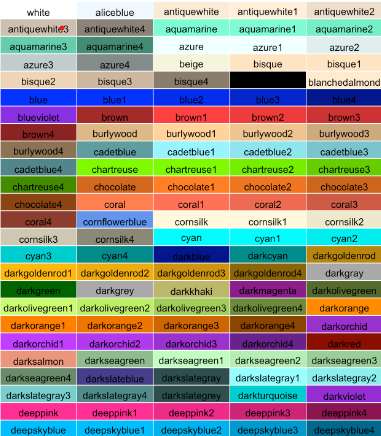

  - Number: RRGGBB. Ranges from 00 to FF. Using a hex color picker is the best mode here
  - RGB: choosing between 0 and 1. red, green, blue percentages.
  - pal: can also set things under their own pallet.

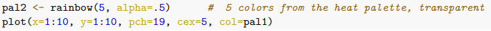

- alpha: opacity / transparency. from 0-1. Needs to be inside “col”
- par: set parameters of the plot. [Source to find more](https://www.rdocumentation.org/packages/graphics/versions/3.6.2/topics/par)

## Playing Around

Dope, now lets play with what we have learned a bit.

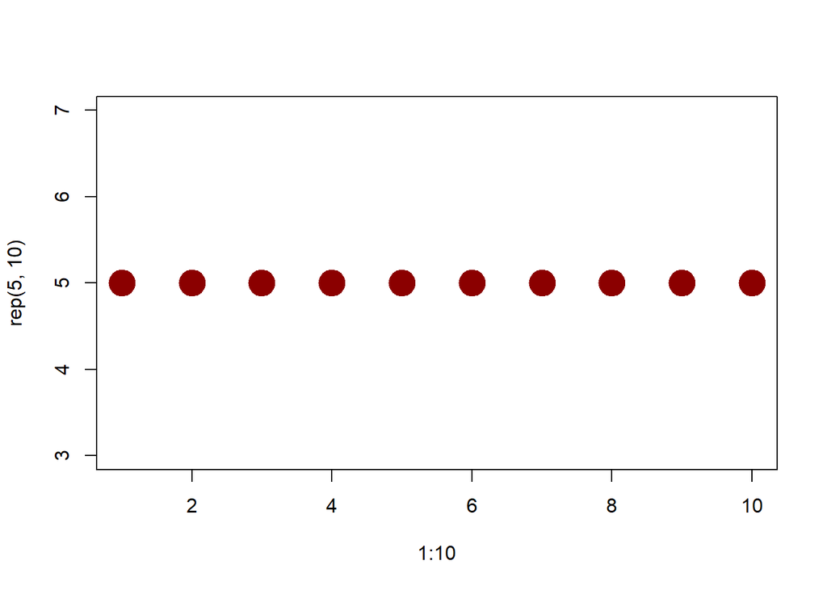

```r
plot(x=1:10, y=rep(5,10), pch=19, cex=3, col="dark red")
```

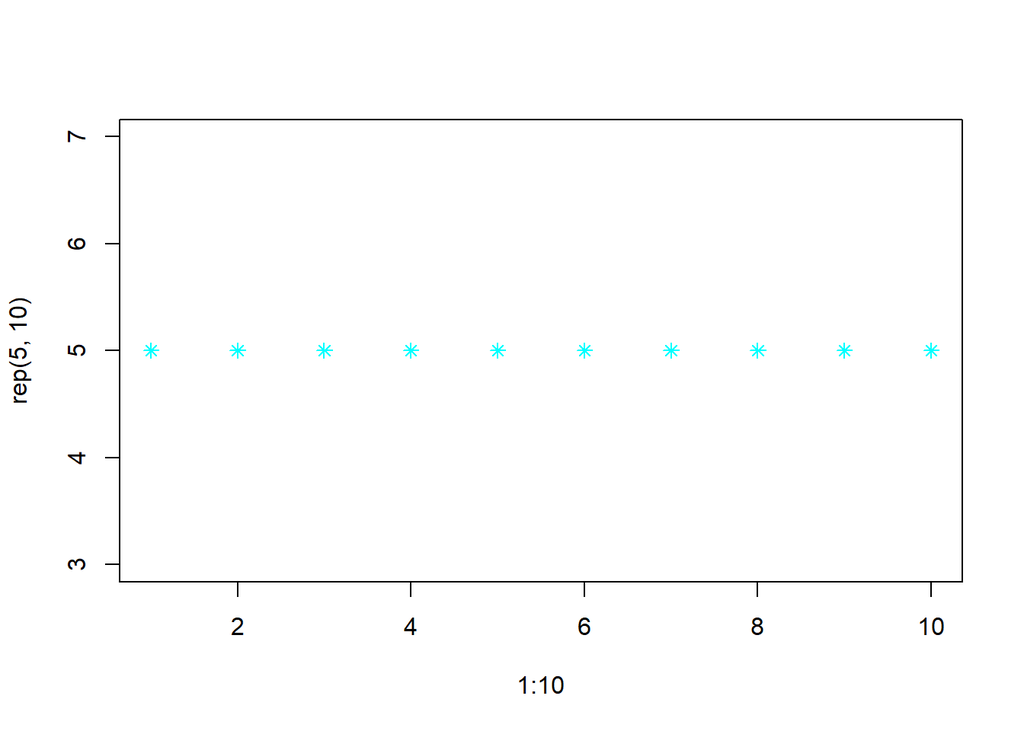

```r
plot(x=1:10, y=rep(5,10), pch=8, cex=1, col="cyan")
```

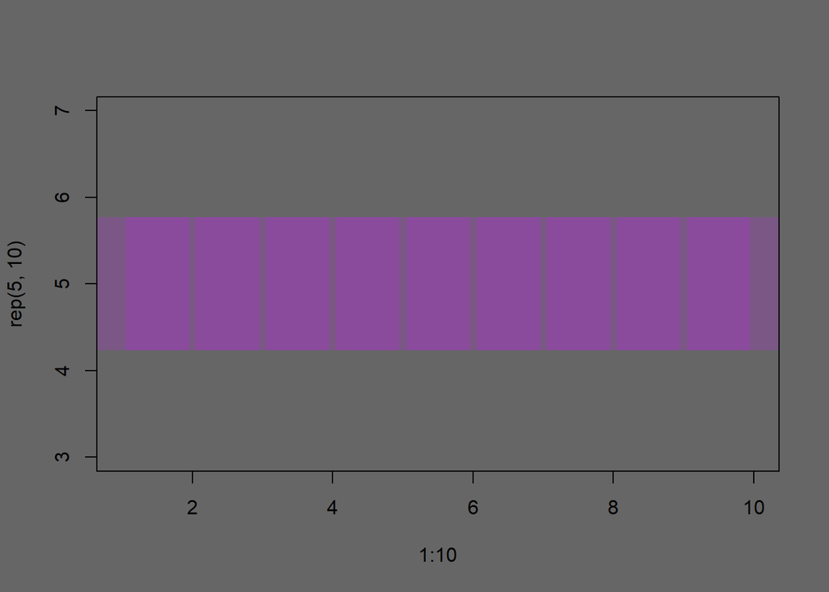

```r
par(bg="gray40")
plot(x=1:10, y=rep(5,10), pch=15, cex=15, col=rgb(.8, .1, 1, alpha = .2))
```

# Data Exploration

- The shape of the node signals are often hard to see and left off
- Nodes: specific data points
- Links: connections between them

```r
nodes <- read.csv(file = "files/network 5.16/Dataset1-Media-Example-NODES.csv", header=T, as.is=T)
links <- read.csv("files/network 5.16/Dataset1-Media-Example-EDGES.csv", header=T, as.is=T)

# lets see what the data looks like
head(nodes)
```

```
##    id               media media.type type.label audience.size
## 1 s01            NY Times          1  Newspaper            20
## 2 s02     Washington Post          1  Newspaper            25
## 3 s03 Wall Street Journal          1  Newspaper            30
## 4 s04           USA Today          1  Newspaper            32
## 5 s05            LA Times          1  Newspaper            20
## 6 s06       New York Post          1  Newspaper            50
```

```r
head(links)
```

```
##   from  to      type weight
## 1  s01 s02 hyperlink     22
## 2  s01 s03 hyperlink     22
## 3  s01 s04 hyperlink     21
## 4  s01 s15   mention     20
## 5  s02 s01 hyperlink     23
## 6  s02 s03 hyperlink     21
```

*Question 1*

- Raw data needs to be changed to an igraph network object (*Question 2*). This is done using ‘graph_from_data_frame()’
  - ‘d’: edges (links in this example). *The first two columns need to be the ID of the source and target for each edge*. Attributes can follow.
  - ‘vertices’: nodes. *The first column needs to be the id of the node*. Attributes can follow.

```r
library('igraph')
net <- graph_from_data_frame(d=links, vertices=nodes, directed=T)
net
```

```
## IGRAPH 811bba6 DNW- 17 49 --
## + attr: name (v/c), media (v/c), media.type (v/n), type.label (v/c),
## | audience.size (v/n), type (e/c), weight (e/n)
## + edges from 811bba6 (vertex names):
##  [1] s01->s02 s01->s03 s01->s04 s01->s15 s02->s01 s02->s03 s02->s09 s02->s10
##  [9] s03->s01 s03->s04 s03->s05 s03->s08 s03->s10 s03->s11 s03->s12 s04->s03
## [17] s04->s06 s04->s11 s04->s12 s04->s17 s05->s01 s05->s02 s05->s09 s05->s15
## [25] s06->s06 s06->s16 s06->s17 s07->s03 s07->s08 s07->s10 s07->s14 s08->s03
## [33] s08->s07 s08->s09 s09->s10 s10->s03 s12->s06 s12->s13 s12->s14 s13->s12
## [41] s13->s17 s14->s11 s14->s13 s15->s01 s15->s04 s15->s06 s16->s06 s16->s17
## [49] s17->s04
```

```r
E(net)       # The edges of the "net" object
```

```
## + 49/49 edges from 811bba6 (vertex names):
##  [1] s01->s02 s01->s03 s01->s04 s01->s15 s02->s01 s02->s03 s02->s09 s02->s10
##  [9] s03->s01 s03->s04 s03->s05 s03->s08 s03->s10 s03->s11 s03->s12 s04->s03
## [17] s04->s06 s04->s11 s04->s12 s04->s17 s05->s01 s05->s02 s05->s09 s05->s15
## [25] s06->s06 s06->s16 s06->s17 s07->s03 s07->s08 s07->s10 s07->s14 s08->s03
## [33] s08->s07 s08->s09 s09->s10 s10->s03 s12->s06 s12->s13 s12->s14 s13->s12
## [41] s13->s17 s14->s11 s14->s13 s15->s01 s15->s04 s15->s06 s16->s06 s16->s17
## [49] s17->s04
```

```r
V(net)       # The vertices of the "net" object
```

```
## + 17/17 vertices, named, from 811bba6:
##  [1] s01 s02 s03 s04 s05 s06 s07 s08 s09 s10 s11 s12 s13 s14 s15 s16 s17
```

```r
E(net)$type  # Edge attribute "type"
```

```
##  [1] "hyperlink" "hyperlink" "hyperlink" "mention"   "hyperlink" "hyperlink"
##  [7] "hyperlink" "hyperlink" "hyperlink" "hyperlink" "hyperlink" "hyperlink"
## [13] "mention"   "hyperlink" "hyperlink" "hyperlink" "mention"   "mention"
## [19] "hyperlink" "mention"   "mention"   "hyperlink" "hyperlink" "mention"
## [25] "hyperlink" "hyperlink" "mention"   "mention"   "mention"   "hyperlink"
## [31] "mention"   "hyperlink" "mention"   "mention"   "mention"   "hyperlink"
## [37] "mention"   "hyperlink" "mention"   "hyperlink" "mention"   "mention"
## [43] "mention"   "hyperlink" "hyperlink" "hyperlink" "hyperlink" "mention"
## [49] "hyperlink"
```

```r
V(net)$media # Vertex attribute "media"
```

```
##  [1] "NY Times"            "Washington Post"     "Wall Street Journal"
##  [4] "USA Today"           "LA Times"            "New York Post"
##  [7] "CNN"                 "MSNBC"               "FOX News"
## [10] "ABC"                 "BBC"                 "Yahoo News"
## [13] "Google News"         "Reuters.com"         "NYTimes.com"
## [16] "WashingtonPost.com"  "AOL.com"
```

```r
# Get an edge list or a matrix:
as_edgelist(net, names=T)
```

```
##       [,1]  [,2]
##  [1,] "s01" "s02"
##  [2,] "s01" "s03"
##  [3,] "s01" "s04"
##  [4,] "s01" "s15"
##  [5,] "s02" "s01"
##  [6,] "s02" "s03"
##  [7,] "s02" "s09"
##  [8,] "s02" "s10"
##  [9,] "s03" "s01"
## [10,] "s03" "s04"
## [11,] "s03" "s05"
## [12,] "s03" "s08"
## [13,] "s03" "s10"
## [14,] "s03" "s11"
```

[output cut: 35 more lines]

```r
as_adjacency_matrix(net, attr="weight")
```

```
## 17 x 17 sparse Matrix of class "dgCMatrix"
##
## s01  . 22 22 21 .  .  .  .  .  .  .  .  .  . 20  .  .
## s02 23  . 21  . .  .  .  .  1  5  .  .  .  .  .  .  .
## s03 21  .  . 22 1  .  .  4  .  2  1  1  .  .  .  .  .
## s04  .  . 23  . .  1  .  .  .  . 22  3  .  .  .  .  2
## s05  1 21  .  . .  .  .  .  2  .  .  .  .  . 21  .  .
## s06  .  .  .  . .  1  .  .  .  .  .  .  .  .  . 21 21
## s07  .  .  1  . .  .  . 22  . 21  .  .  .  4  .  .  .
## s08  .  .  2  . .  . 21  . 23  .  .  .  .  .  .  .  .
## s09  .  .  .  . .  .  .  .  . 21  .  .  .  .  .  .  .
## s10  .  .  2  . .  .  .  .  .  .  .  .  .  .  .  .  .
## s11  .  .  .  . .  .  .  .  .  .  .  .  .  .  .  .  .
## s12  .  .  .  . .  2  .  .  .  .  .  . 22 22  .  .  .
## s13  .  .  .  . .  .  .  .  .  .  . 21  .  .  .  .  1
## s14  .  .  .  . .  .  .  .  .  .  1  . 21  .  .  .  .
## s15 22  .  .  1 .  4  .  .  .  .  .  .  .  .  .  .  .
## s16  .  .  .  . . 23  .  .  .  .  .  .  .  .  .  . 21
## s17  .  .  .  4 .  .  .  .  .  .  .  .  .  .  .  .  .
```

```r
# Or data frames describing nodes and edges:
as_data_frame(net, what="edges")
```

```
##    from  to      type weight
## 1   s01 s02 hyperlink     22
## 2   s01 s03 hyperlink     22
## 3   s01 s04 hyperlink     21
## 4   s01 s15   mention     20
## 5   s02 s01 hyperlink     23
## 6   s02 s03 hyperlink     21
## 7   s02 s09 hyperlink      1
## 8   s02 s10 hyperlink      5
## 9   s03 s01 hyperlink     21
## 10  s03 s04 hyperlink     22
## 11  s03 s05 hyperlink      1
## 12  s03 s08 hyperlink      4
## 13  s03 s10   mention      2
## 14  s03 s11 hyperlink      1
```

[output cut: 35 more lines]

```r
as_data_frame(net, what="vertices")
```

```
##     name               media media.type type.label audience.size
## s01  s01            NY Times          1  Newspaper            20
## s02  s02     Washington Post          1  Newspaper            25
## s03  s03 Wall Street Journal          1  Newspaper            30
## s04  s04           USA Today          1  Newspaper            32
## s05  s05            LA Times          1  Newspaper            20
## s06  s06       New York Post          1  Newspaper            50
## s07  s07                 CNN          2         TV            56
## s08  s08               MSNBC          2         TV            34
## s09  s09            FOX News          2         TV            60
## s10  s10                 ABC          2         TV            23
## s11  s11                 BBC          2         TV            34
## s12  s12          Yahoo News          3     Online            33
## s13  s13         Google News          3     Online            23
## s14  s14         Reuters.com          3     Online            12
## s15  s15         NYTimes.com          3     Online            24
## s16  s16  WashingtonPost.com          3     Online            28
## s17  s17             AOL.com          3     Online            33
```

- This is cool because it lets us see some of the specifics. This helps me frame things easier in my mind. I feel like this helps me conceptualize the data a little bit better, as it shows where the edges should be as well as how the edges are. Also, the vertexes would be what is considered the different aspects having a relationship, while the edges show the relationship itself. (*Question 3*)

## Now, let’s plot the thing:

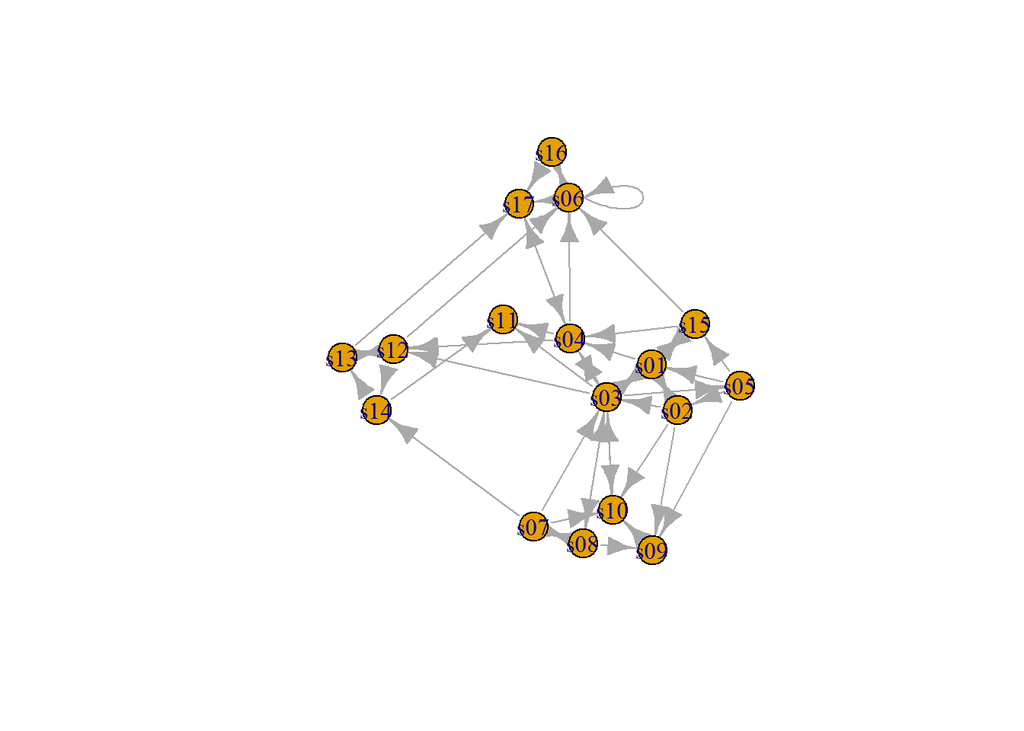

```r
plot(net) # not a pretty picture!
```

- Interestingly, there is a loop you can see from s06 to itself. Those loops can be removed:

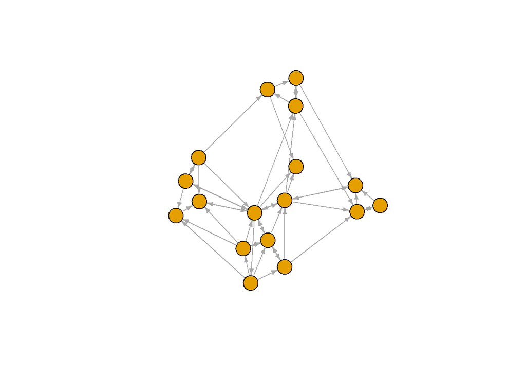

```r
net <- simplify(net, remove.multiple = F, remove.loops = T)

plot(net, edge.arrow.size=.4,vertex.label=NA)
```

- This plot looks okay, but let’s play with it now, shall we? The options are listed below:

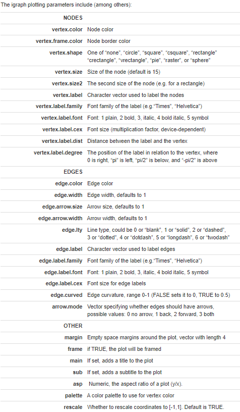

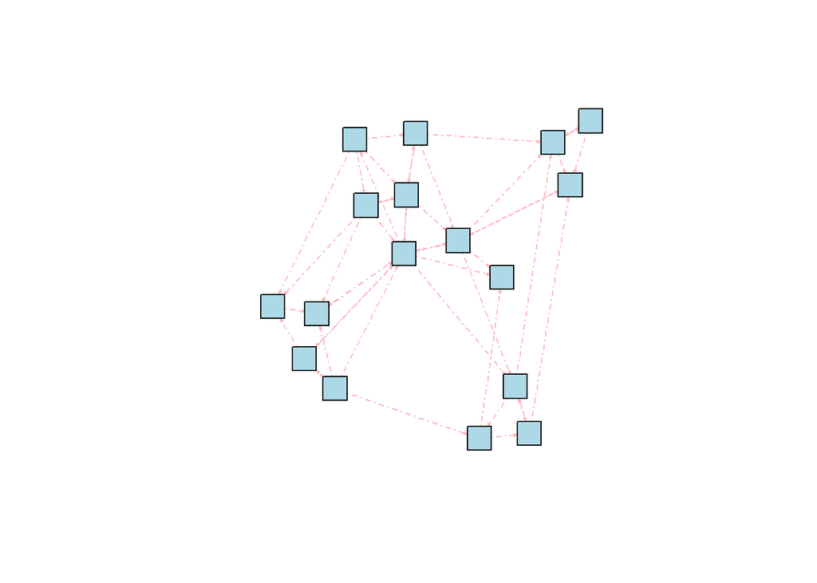

```r
plot(net, vertex.color="lightblue", vertex.shape="square", edge.curved=0, vertex.label=NA, edge.lty=4, arrow.mode=3, edge.color="lightpink", frame=TRUE, edge.arrow.size=.15)
```

- If we want to change the labels to text, we can do so by doing this:

```r
V(net)$media
```

```
##  [1] "NY Times"            "Washington Post"     "Wall Street Journal"
##  [4] "USA Today"           "LA Times"            "New York Post"
##  [7] "CNN"                 "MSNBC"               "FOX News"
## [10] "ABC"                 "BBC"                 "Yahoo News"
## [13] "Google News"         "Reuters.com"         "NYTimes.com"
## [16] "WashingtonPost.com"  "AOL.com"
```

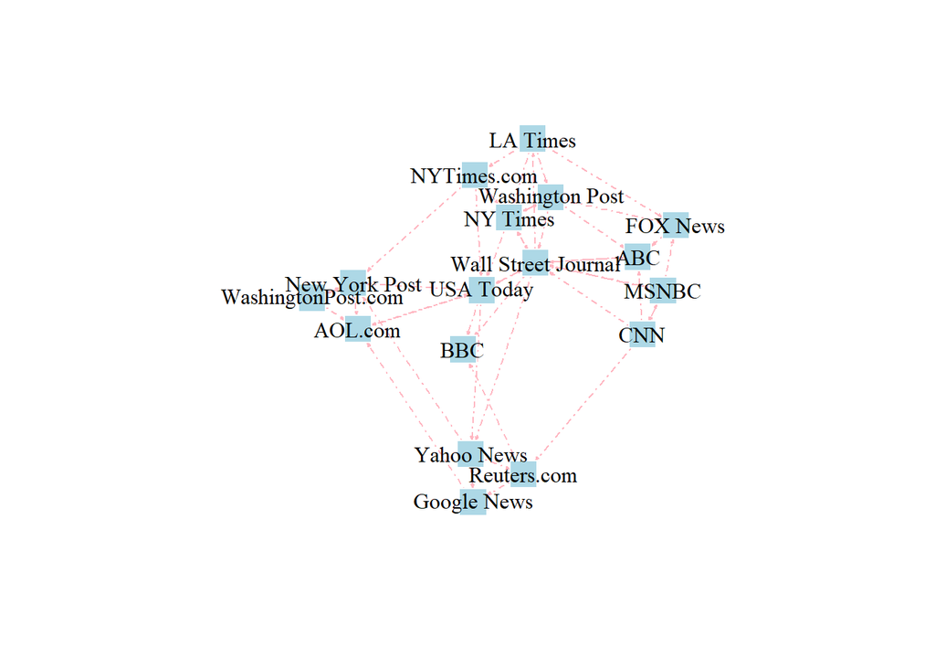

```r
plot(net, vertex.label=V(net)$media, vertex.color="lightblue", vertex.shape="square", edge.curved=0, vertex.label=NA, edge.lty=4, arrow.mode=3, edge.color="lightpink", frame=TRUE, edge.arrow.size=.15, vertex.frame.color="#ffffff", vertex.label.color="black")
```

- Now, how about changing things based on the igrapj object?

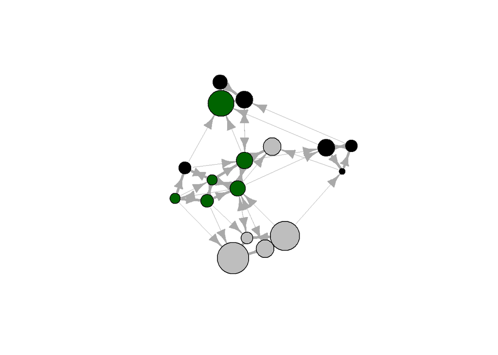

```r
# Generate colors based on media type:
colrs <- c("darkgreen", "gray", "black")
V(net)$color <- colrs[V(net)$media.type]

# Compute node degrees (#links) and use that to set node size:
deg <- degree(net, mode="all")
V(net)$size <- deg*1
V(net)$size <- V(net)$audience.size*0.6
V(net)$label <- NA
E(net)$width <- E(net)$weight/6

plot(net)
```

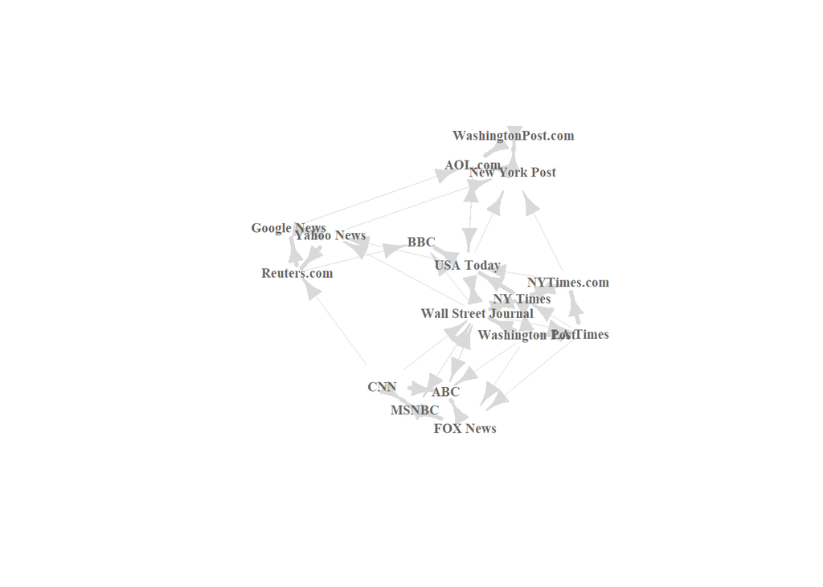

```r
plot(net, vertex.shape="none", vertex.label=V(net)$media,
     vertex.label.font=2, vertex.label.color="gray40",
     vertex.label.cex=.7, edge.color="gray85")
```